# Exercises 7

Giovanni Zurlo

29/11/2021

> *Run the following clusterings and compare them using MDS plots based on the simple matching distance. Also compute ARIs for every pair of clusterings. Where you compare one clustering based on electioncomplete with 1311 observations and one clustering based on electionwithna with 1785 observations, only use the 1311 observations without missing values for the ARI computation.*

```r
library(poLCA)
data(election)

election12 <- election[,1:12]
electioncomplete <- election12[complete.cases(election12),] # 1311 obs.

electionwithna <- election12
for (i in 1:12){
  levels(electionwithna[,i]) <- c(levels(election12[,i]),"NA")
  electionwithna[is.na(election12[,i]),i] <- "NA"}

sm.complete <- sm(electioncomplete)
sm.withna <- sm(electionwithna)
mds.complete <- mds(sm.complete,type = 'ratio')
mds.withna <- mds(sm.withna,type = 'ratio')
```

ㅤ

#### **[a]ㅤㅤpoLCA(3) on election12**

```
## poLCA(formula = f, data = election12, nclass = 3, maxiter = 5000,
##     nrep = 50)
```

```
## Conditional item response (column) probabilities,
##  by outcome variable, for each class (row)
##
## $MORALG
##           1 Extremely well 2 Quite well 3 Not too well 4 Not well at all
## class 1:            0.1851       0.3668         0.2350            0.2131
## class 2:            0.1013       0.5990         0.2552            0.0446
## class 3:            0.5224       0.4109         0.0390            0.0277
##
## $CARESG
##           1 Extremely well 2 Quite well 3 Not too well 4 Not well at all
## class 1:            0.0879       0.2546         0.3524            0.3051
## class 2:            0.0227       0.5090         0.3819            0.0864
## class 3:            0.3970       0.4605         0.0895            0.0529
##
## $KNOWG
##           1 Extremely well 2 Quite well 3 Not too well 4 Not well at all
## class 1:            0.2542       0.4253         0.2382            0.0822
## class 2:            0.0429       0.8058         0.1408            0.0105
## class 3:            0.5878       0.3543         0.0266            0.0312
##
## $LEADG
##           1 Extremely well 2 Quite well 3 Not too well 4 Not well at all
## class 1:            0.0747       0.2582         0.3856            0.2816
## class 2:            0.0207       0.4886         0.4268            0.0639
## class 3:            0.3747       0.4772         0.1085            0.0396
##
## $DISHONG
##           1 Extremely well 2 Quite well 3 Not too well 4 Not well at all
## class 1:            0.2007       0.3060         0.2774            0.2158
## class 2:            0.0519       0.2182         0.4998            0.2301
## class 3:            0.0426       0.0487         0.3371            0.5717
##
## $INTELG
##           1 Extremely well 2 Quite well 3 Not too well 4 Not well at all
## class 1:            0.2936       0.4407         0.1852            0.0805
## class 2:            0.0600       0.7953         0.1317            0.0130
## class 3:            0.5763       0.3698         0.0197            0.0341
##
## $MORALB
```

[output cut: 39 more lines]

```
##  0.2578 0.4256 0.3166
##
## =========================================================
## Fit for 3 latent classes:
## =========================================================
## number of observations: 1311
## number of estimated parameters: 110
## residual degrees of freedom: 1201
## maximum log-likelihood: -16714.66
##
## AIC(3): 33649.32
## BIC(3): 34218.96
## G^2(3): 15016.7 (Likelihood ratio/deviance statistic)
## X^2(3): 16748690644 (Chi-square goodness of fit)
##
```

ㅤ

#### **[b]ㅤㅤpoLCA(3) on electionwithna**

```
## poLCA(formula = f, data = electionwithna, nclass = 3, maxiter = 5000,
##     nrep = 50)
```

```
## Conditional item response (column) probabilities,
##  by outcome variable, for each class (row)
##
## $MORALG
##           1 Extremely well 2 Quite well 3 Not too well 4 Not well at all     NA
## class 1:            0.1069       0.4510         0.2755            0.1321 0.0345
## class 2:            0.4680       0.4895         0.0286            0.0060 0.0079
## class 3:            0.0576       0.4082         0.1332            0.0660 0.3351
##
## $CARESG
##           1 Extremely well 2 Quite well 3 Not too well 4 Not well at all     NA
## class 1:            0.0333       0.3201         0.4160            0.2051 0.0255
## class 2:            0.3371       0.5429         0.0867            0.0252 0.0081
## class 3:            0.0769       0.2832         0.2050            0.1594 0.2756
##
## $KNOWG
##           1 Extremely well 2 Quite well 3 Not too well 4 Not well at all     NA
## class 1:            0.1194       0.6230         0.1978            0.0496 0.0102
## class 2:            0.4990       0.4824         0.0131            0.0055 0.0000
## class 3:            0.0818       0.5479         0.1376            0.0513 0.1814
##
## $LEADG
##           1 Extremely well 2 Quite well 3 Not too well 4 Not well at all     NA
## class 1:            0.0282       0.3112         0.4574            0.1851 0.0179
## class 2:            0.3298       0.5560         0.1017            0.0049 0.0076
## class 3:            0.0394       0.3353         0.2541            0.0966 0.2746
##
## $DISHONG
##           1 Extremely well 2 Quite well 3 Not too well 4 Not well at all     NA
## class 1:            0.1248       0.2687         0.3919            0.1771 0.0375
## class 2:            0.0247       0.0634         0.3563            0.5322 0.0235
## class 3:            0.0412       0.1604         0.2142            0.1767 0.4075
##
## $INTELG
##           1 Extremely well 2 Quite well 3 Not too well 4 Not well at all     NA
## class 1:            0.1511       0.6238         0.1649            0.0509 0.0093
## class 2:            0.5060       0.4691         0.0188            0.0061 0.0000
## class 3:            0.0876       0.5720         0.1144            0.0683 0.1577
##
## $MORALB
```

[output cut: 39 more lines]

```
##  0.4756 0.3815 0.1429
##
## =========================================================
## Fit for 3 latent classes:
## =========================================================
## number of observations: 1785
## number of estimated parameters: 146
## residual degrees of freedom: 1639
## maximum log-likelihood: -25885.25
##
## AIC(3): 52062.51
## BIC(3): 52863.64
## G^2(3): 25461.92 (Likelihood ratio/deviance statistic)
## X^2(3): 12552832011 (Chi-square goodness of fit)
##
```

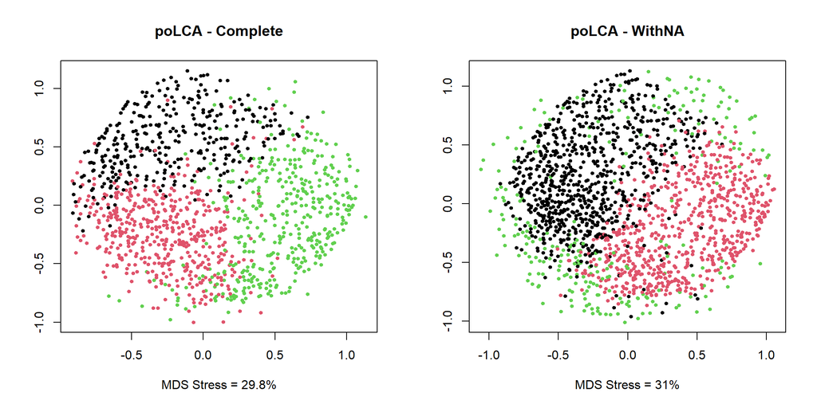

ㅤ

#### **[c]ㅤㅤflexmixedruns(3) on electioncomplete**

```
##
## Call:
## flexmix(formula = x ~ 1, k = k, cluster = initial.cluster, model = lcmixed(continuous = continuous,
##     discrete = discrete, ppdim = ppdim, diagonal = diagonal),
##     control = control)
##
##        prior size post>0 ratio
## Comp.1 0.261  338    885 0.382
## Comp.2 0.418  555   1008 0.551
## Comp.3 0.321  418    986 0.424
##
## 'log Lik.' -16714.69 (df=110)
## AIC: 33649.38   BIC: 34219.02
```

ㅤ

#### **[d]ㅤㅤflexmixedruns(3) on electionwithna**

```
##
## Call:
## flexmix(formula = x ~ 1, k = k, cluster = initial.cluster, model = lcmixed(continuous = continuous,
##     discrete = discrete, ppdim = ppdim, diagonal = diagonal),
##     control = control)
##
##        prior size post>0 ratio
## Comp.1 0.146  256   1278 0.200
## Comp.2 0.475  853   1352 0.631
## Comp.3 0.379  676   1329 0.509
##
## 'log Lik.' -25885.28 (df=146)
## AIC: 52062.56   BIC: 52863.69
```

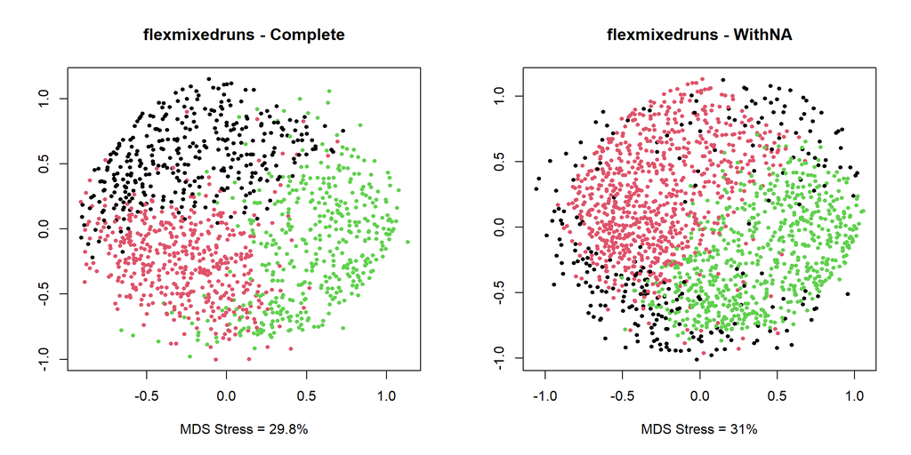

We have an exact correspondence between mixtures estimated by means of different functions, on the same dataset (same BIC values and ARI ≈ 1). The inclusion of 474 observations with missing values has a remarkable impact on clusterings, with ARI dropping to about 0.34.

ㅤ

#### **[e]ㅤㅤPAM (3) on electioncomplete**

```
## pam(x = sm.complete, k = 3, diss = T, nstart = 100, trace.lev = 1)
```

```
##      size  max_diss   av_diss diameter separation
## [1,]  703 0.8333333 0.3879801        1 0.08333333
## [2,]  248 0.9166667 0.4398522        1 0.08333333
## [3,]  360 0.9166667 0.4127315        1 0.08333333
```

```
## [1] Cluster Avg Silhouette Width:
```

```
## [1] 0.131 0.188 0.131
```

```
## [1] Average Silhouette Width:  0.142
```

ㅤ ㅤ

#### **[f]ㅤㅤPAM (3) on electionwithna**

```
## pam(x = sm.withna, k = 3, diss = T, nstart = 100, trace.lev = 1)
```

```
##      size  max_diss   av_diss diameter separation
## [1,]  970 1.0000000 0.4276632        1 0.08333333
## [2,]  489 0.9166667 0.4386503        1 0.08333333
## [3,]  326 0.9166667 0.4624233        1 0.08333333
```

```
## [1] Cluster Avg Silhouette Width:
```

```
## [1] 0.101 0.122 0.181
```

```
## [1] Average Silhouette Width:  0.121
```

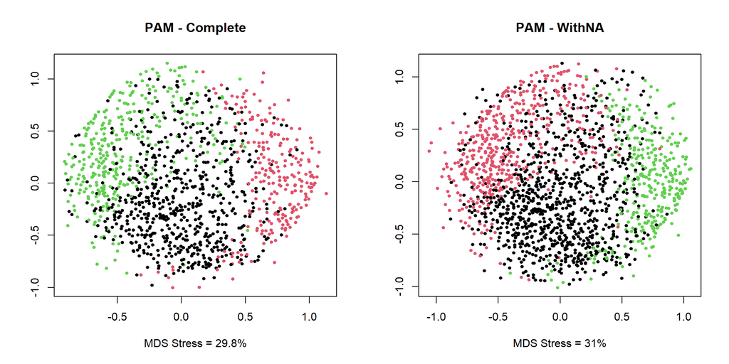

Surprisingly, the introduction of NAs as a new categorical value has no effect on PAM algorithm. This can be seen roughly from the plots, ignoring label switching, and from the ARI table below (*ARI[e,f] ≈ 1*)

ㅤ ㅤ

#### **[g]ㅤㅤPAM (3) on Gower Dissimilarity Matrix**

I was supposed to compute a dissimilarity-based clustering on Gower dissimilarity matrix (which allows for missing values by definition). However, I obtained a matrix containing several NAs, due to the fact that for some observations there was no information with which to compute the dissimilarity. I decided to discard vectors containing NAs from the matrix, while still preserving information about more observations (**1466**) than those kept in *electioncomplete* (**1311**). Final clustering is, however, very dissimilar from all the others.

```r
gower=daisy(election12,metric = 'gower')
# Dissimilarity computed for all 1785 obs, with NAs
attributes(gower)$Size
```

```
## [1] 1785
```

```r
attributes(gower)$NA.message
```

```
## [1] "NA-values in the dissimilarity matrix !"
```

```r
# Removing NAs from the Dissimilarity Matrix
gower2 = as.matrix(gower)
gower2 = gower2[rowSums(is.na(gower2)) == 0, colSums(is.na(gower2)) == 0, drop = FALSE]
gower2 = as.dist(gower2)

attributes(gower2)$NA.message
```

```r
attributes(gower2)$Size
```

```
## [1] 1466
```

```r
# Running PAM on this obtained Gower DissMat - Printing Summary
```

```
## pam(x = gower.mod, k = 3, diss = T, nstart = 150, trace.lev = 1)
```

```
##      size  max_diss   av_diss diameter separation
## [1,]  888 0.8888889 0.3441231        1 0.00000000
## [2,]  295 0.9000000 0.4233239        1 0.00000000
## [3,]  283 0.8181818 0.4674733        1 0.08333333
```

```
## [1] Cluster Avg Silhouette Width:
```

```
## [1] 0.192 0.197 0.104
```

```
## [1] Average Silhouette Width:  0.176
```

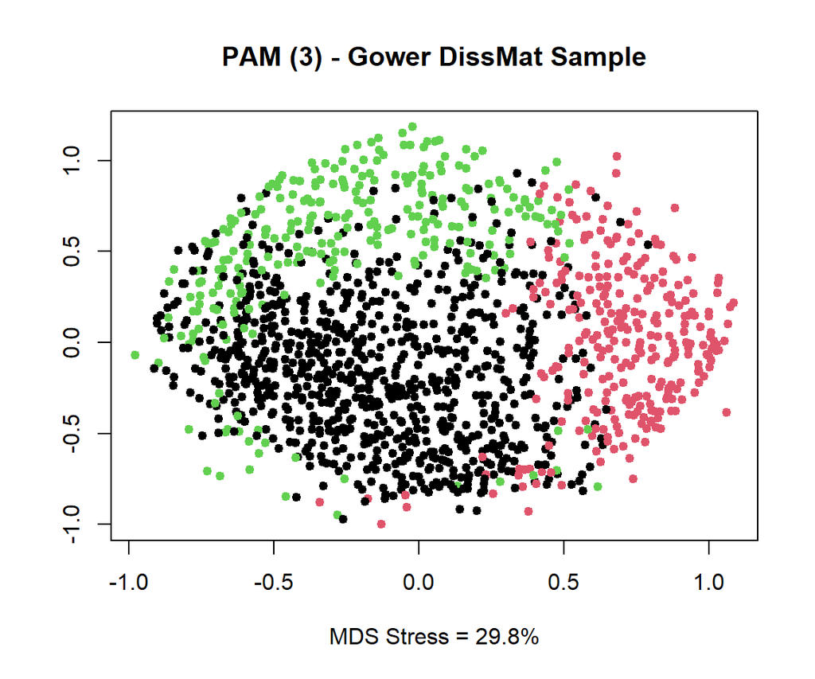

ㅤ ㅤ

#### **[h]ㅤㅤflexmixedruns on electionwithna with estimated K**

```
##
## Call:
## flexmix(formula = x ~ 1, k = k, cluster = initial.cluster, model = lcmixed(continuous = continuous,
##     discrete = discrete, ppdim = ppdim, diagonal = diagonal),
##     control = control)
##
##         prior size post>0 ratio
## Comp.1 0.1150  205    938 0.219
## Comp.2 0.1793  328    994 0.330
## Comp.3 0.1393  248    694 0.357
## Comp.4 0.0990  177    850 0.208
## Comp.5 0.0734  126    452 0.279
## Comp.6 0.0618  107    617 0.173
## Comp.7 0.2003  364   1037 0.351
## Comp.8 0.1318  230    916 0.251
##
## 'log Lik.' -23908.85 (df=391)
## AIC: 48599.69   BIC: 50745.18
```

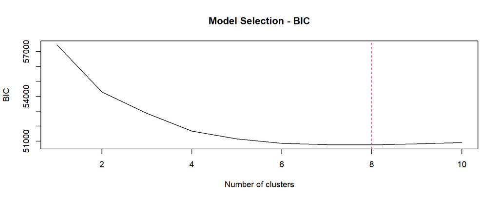

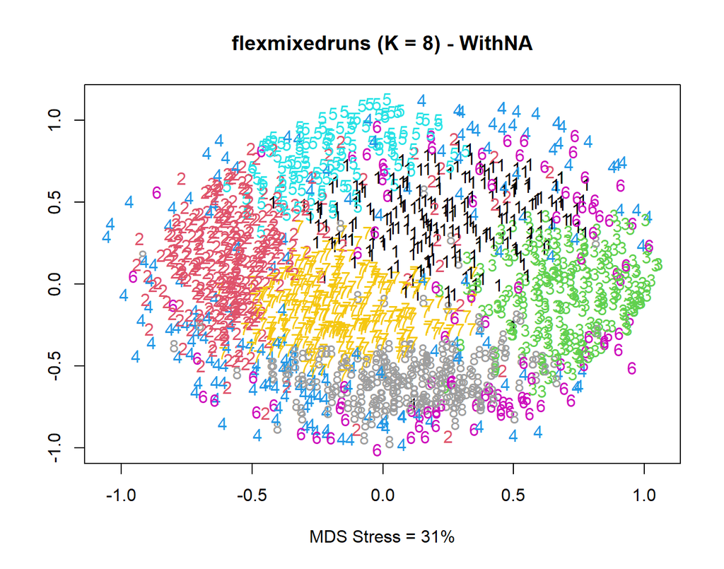

```r
results=list()
results[[1]]=a$predclass
results[[2]]=b.c
results[[3]]=c$flexout[[3]]@cluster
results[[4]]=d.c
results[[5]]=e$clustering
results[[6]]=f.c
results[[7]]=g.c
results[[8]]=h.c

labels=c('a','b','c','d','e','f','g','h')
results=setNames(object=results,labels)

ARI=matrix(NA,nrow = 8,ncol = 8, dimnames = list(labels,labels))

for (i in 1:8) {
  for (j in 1:8) {ARI[i,j]=adjustedRandIndex(results[[i]],results[[j]])}
}

library(kableExtra)
ARI |>
kable("html", caption = 'Clusterings Pairwise Comparisons (ARI)', row.names = T) |>
  kable_styling(full_width = F, position = "center")
```

Clusterings Pairwise Comparisons (ARI)

|  | a | b | c | d | e | f | g | h |
| --- | --- | --- | --- | --- | --- | --- | --- | --- |
| a | 1.0000000 | 0.3434794 | 0.9925231 | 0.3469236 | 0.1848456 | 0.1848456 | -0.0013211 | 0.3001994 |
| b | 0.3434794 | 1.0000000 | 0.3467672 | 0.9880599 | 0.1503675 | 0.1503675 | 0.0035137 | 0.1884477 |
| c | 0.9925231 | 0.3467672 | 1.0000000 | 0.3502484 | 0.1846130 | 0.1846130 | -0.0011922 | 0.3012143 |
| d | 0.3469236 | 0.9880599 | 0.3502484 | 1.0000000 | 0.1500921 | 0.1500921 | 0.0044629 | 0.1887584 |
| e | 0.1848456 | 0.1503675 | 0.1846130 | 0.1500921 | 1.0000000 | 1.0000000 | -0.0029834 | 0.2136153 |
| f | 0.1848456 | 0.1503675 | 0.1846130 | 0.1500921 | 1.0000000 | 1.0000000 | -0.0029834 | 0.2136153 |
| g | -0.0013211 | 0.0035137 | -0.0011922 | 0.0044629 | -0.0029834 | -0.0029834 | 1.0000000 | 0.0012860 |
| h | 0.3001994 | 0.1884477 | 0.3012143 | 0.1887584 | 0.2136153 | 0.2136153 | 0.0012860 | 1.0000000 |

ㅤ

## **Exercise 2**

> *For two different latent class clusterings computed in question 1 on the electionwithna-data produce heatmaps as on slide 276 of the course notes. Comment on the plots. Do you find the clusters convincing? Why or why not? Is there evidence against local independence?*

ㅤ

#### **ㅤㅤㅤㅤㅤㅤㅤㅤㅤㅤㅤㅤㅤㅤHeatplot for PAM (3) on electionwithna**

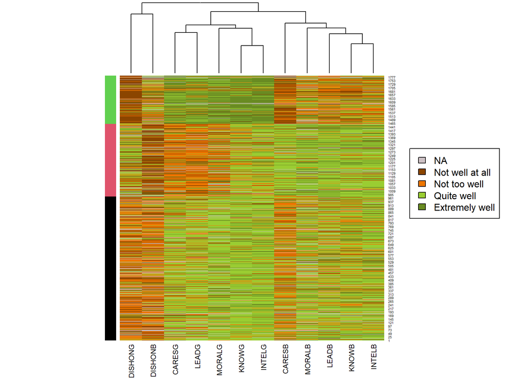

ㅤ

ㅤ

#### **ㅤㅤㅤㅤㅤㅤㅤㅤㅤㅤㅤㅤHeatplot for flexmixedruns (8) on electionwithna**

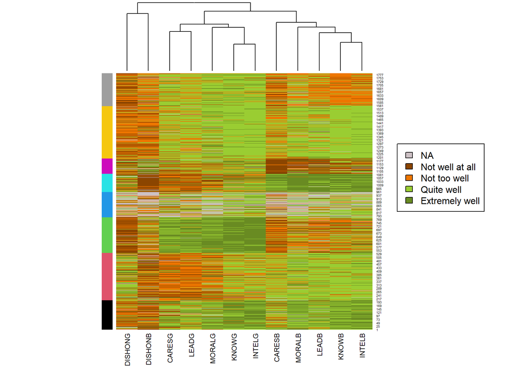

ㅤ

ㅤ

## **Exercise 3**

> *Assume a situation with 10 categorical variables. Five variables are binary, three variables have three categories, and two variables have five categories. What is the number of free parameters for…*

#### **a general categorical model that models all possible probabilities**

```r
p <- 10
# Creating a vector of lenght p with the number of categories mj
mj <- c(rep(2,5),rep(3,3),rep(5,2))
# Computing the number of free parameters
prod(mj-1)
```

```
## [1] 128
```

Since *n* vectors of dimension *p* can fit up to *np* df, here we would need at least **13** observations.

ㅤ

#### **a latent class mixture model with 4 mixture components**

```r
K <- 4
# Computing the number of free parameters
(K-1) + K*sum(mj-1)
```

```
## [1] 79
```

```r
(K-1) + K*sum(mj-1) < prod(mj-1)
```

```
## [1] TRUE
```

Smaller df (and required sample size) than a fully general categorical model.

ㅤ

> *Consider a situation where observations X = (X1;X2;X3) have 3 categorical variables, all binary with values 0 and 1. Consider a latent class mixture with three components (clusters), and the given parameters. Compute:*

#### **the *dof* that this model has, and the *dof* of a general categorical model**

```r
mj <- rep(2,3)
K <- 3
# Computing dof of a general multinomial model
prod(mj-1)
```

```
## [1] 1
```

```r
# Computing dof of a latent class mixture with K=3
(K-1) + K*sum(mj-1)
```

```
## [1] 11
```

ㅤ

#### **Probabilities for all possible observations**

```r
bin=c(0,1)
obs=expand.grid(bin,bin,bin)

g_x.y1=numeric()
g_x.y1[1]=(0.9)^3
g_x.y1[2]=0.1*(0.9)^2
g_x.y1[3]=0.1*(0.9)^2
g_x.y1[4]=((0.1)^2)*0.9
g_x.y1[5]=0.1*(0.9)^2
g_x.y1[6]=((0.1)^2)*0.9
g_x.y1[7]=((0.1)^2)*0.9
g_x.y1[8]=(0.1)^3

g_x.y2=numeric()
g_x.y2[1]=(0.5)^3
g_x.y2[2]=(0.5)^3
g_x.y2[3]=(0.5)^3
g_x.y2[4]=(0.5)^3
g_x.y2[5]=(0.5)^3
g_x.y2[6]=(0.5)^3
g_x.y2[7]=(0.5)^3
g_x.y2[8]=(0.5)^3

g_x.y3=numeric()
g_x.y3[1]=(0.2)^3
g_x.y3[2]=0.8*(0.2)^2
g_x.y3[3]=0.8*(0.2)^2
g_x.y3[4]=((0.8)^2)*0.2
g_x.y3[5]=0.8*(0.2)^2
g_x.y3[6]=((0.8)^2)*0.2
g_x.y3[7]=((0.8)^2)*0.2
g_x.y3[8]=(0.8)^3

f_x=(g_x.y1/3 + g_x.y2/3 + g_x.y3/3)
```

Conditional and Marginal Probabilites

| X1 | X2 | X3 | g(x\|y=1) | g(x\|y=2) | g(x\|y=3) | f(x) |
| --- | --- | --- | --- | --- | --- | --- |
| 0 | 0 | 0 | 0.729 | 0.125 | 0.008 | 0.2873 |
| 1 | 0 | 0 | 0.081 | 0.125 | 0.032 | 0.0793 |
| 0 | 1 | 0 | 0.081 | 0.125 | 0.032 | 0.0793 |
| 1 | 1 | 0 | 0.009 | 0.125 | 0.128 | 0.0873 |
| 0 | 0 | 1 | 0.081 | 0.125 | 0.032 | 0.0793 |
| 1 | 0 | 1 | 0.009 | 0.125 | 0.128 | 0.0873 |
| 0 | 1 | 1 | 0.009 | 0.125 | 0.128 | 0.0873 |
| 1 | 1 | 1 | 0.001 | 0.125 | 0.512 | 0.2127 |

ㅤ